# Reproducible package for ‘Using mobile Devices as Scientific Measurement Instruments: Reliable Android Task Scheduling’ - Experiment 0

Alberto González, [GEOTEC research group](http://geotec.uji.es/), Universitat Jaume I of Castellón, Spain]

Miguel Matey, [GEOTEC research group](http://geotec.uji.es/), Universitat Jaume I of Castellón, Spain]

Carlos Granell, [GEOTEC research group](http://geotec.uji.es/), Universitat Jaume I of Castellón, Spain]

Sven Casteleyn, [GEOTEC research group](http://geotec.uji.es/), Universitat Jaume I of Castellón, Spain]

12/Nov/2021 (updated 16 noviembre, 2021)

Abstract

This document analyses the result of a basic experiment, Experiment 0, in which no special actions are taken to run a periodic task for data collection on different mobile phones.

Required libraries and runtime environment description are as follows.

```r
library(tidyverse)
library(kableExtra)
library(here)
library(lubridate)
library(stringr)
library(scales)
library(grid)
library(gridBase)
library(gridExtra)
library(patchwork)
```

We ran a simple experiment (Experiment 0) on early November 2021. Collected data were stored in CSV files, one per device. File names start with `SI_`.

# 1 Data preparation

Raw data files are cleaned and merged together into a single file `exp0/data/data_journal.[csv|rds]`. Total observations: 1895. Key variables, as explained below, are computed too.

- quantitative (interval)
  - `plan_date` (*POSIXct, POSIXt*): task planning time.
  - `exec_date` (*POSIXct, POSIXt*): task execution time.
  - `step`: relative position
- quantitative (ratio)
  - `diff` (*difftime*): difference in seconds between the current and previous execution times.
  - `diff_secs` (*numeric*): numeric value of `diff`.
  - `delay` (*numeric*): normalised execution delay in seconds (`diff_secs` - 60).
- categorical (nominal)
  - `device_id`: device identifier
  - `device_name`: device name
  - `device_os`: Android OS version
  - `scheduler`: scheduler type

# 2 Results

## 2.1 List of mobile devices for experimentation (Table 1 in the paper)

Below, the list of mobile devices used for the 3 experiments. Here, we focus on Experiment 0.

```r
knitr::kable(devices %>%
               dplyr::select(ID = id,
                             Device = device,
                             `Android OS` = os,
                             `Exp. 0` = exp_0,
                             `Exp. 1` = exp_1,
                             `Exp. 2` = exp_2),
             format = "html",
             booktabs = TRUE,
             caption = "TABLE 1. Mobile devices used for experimentation") %>%
  kableExtra::kable_styling(full_width = TRUE, bootstrap_options = c("condensed"))
```

TABLE 1. Mobile devices used for experimentation

| ID | Device | Android OS | Exp. 0 | Exp. 1 | Exp. 2 |
| --- | --- | --- | --- | --- | --- |
| NV | Nvidia Shield Tablet (Gen 1) | 7.0 | TRUE | TRUE | TRUE |
| BQ | BQ Aquaris V Plus | 8.1 | TRUE | TRUE | TRUE |
| A1 | Xiaomi Mi A1 | 9.0 | TRUE | TRUE | FALSE |
| H9 | Honor 9 (STF-L09) | 9.0 | TRUE | TRUE | TRUE |
| PO | Poco F2 Pro (M2004J11G) | 11 | FALSE | FALSE | TRUE |

## 2.2 Reliability

### 2.2.1 Completeness

> Completeness (01) is defined as “the extent to which all scheduled tasks are executed”.

We compute the data loss ratio (missingness of data), i.e. the expected number of task executions against the real number of task executions.

```r
missingness$device_os <- forcats::fct_relevel(missingness$device_os, c("7.0", "8.1", "9.0"))

knitr::kable(missingness %>%
               select(`ID` = device_id,
                      `Scheduler` = scheduler,
                      `OS` = device_os,
                      `Start` = start,
                      `End` = end,
                      `# planned executions` = n_plan_exec,
                      `# real executions` = n_real_exec,
                      `% missingness` = percent_lbl),
             format = "html",
             booktabs = TRUE,
             caption = "Missingness of task executions per device and scheduler.") %>%
  kableExtra::kable_styling(full_width = TRUE, bootstrap_options = c("striped", "bordered", "condensed"))
```

Missingness of task executions per device and scheduler.

| ID | Scheduler | OS | Start | End | # planned executions | # real executions | % missingness |
| --- | --- | --- | --- | --- | --- | --- | --- |
| A1 | Simple | 9.0 | 2021-11-05 22:23:19 | 2021-11-07 23:56:17 | 2973 | 1199 | 59.67% |
| BQ | Simple | 8.1 | 2021-11-05 22:23:17 | 2021-11-07 23:58:26 | 2975 | 165 | 94.45% |
| H9 | Simple | 9.0 | 2021-11-08 15:01:17 | 2021-11-10 15:01:00 | 2880 | 181 | 93.72% |
| NV | Simple | 7.0 | 2021-11-05 22:23:12 | 2021-11-07 23:59:09 | 2976 | 350 | 88.24% |

The results largely confirm what is indicated in the literature (*at least* 50% data loss). In fact, the average loss or incompleteness exceeds 80% (see below), which roughly means that 2 out of 10 scheduled observations are collected.

```r
missingness_means <-
  missingness %>%
  dplyr::group_by(scheduler) %>%
  dplyr::summarise(mean = mean(percent)) %>%
  dplyr::mutate(percent_mean = scales::percent(mean, accuracy = 0.1),
                lbl_mean = paste0(mean, " (", percent_mean, ")"))

knitr::kable(missingness_means %>%
               select(`Scheduler` = scheduler,
                      `Avg missingness (%)` = lbl_mean),
             format = "html",
             booktabs = TRUE,
             caption = "Average missingness of tak execution per type of scheduler.") %>%
    kableExtra::kable_styling(full_width = TRUE, bootstrap_options = c("striped", "bordered", "condensed"))
```

Average missingness of tak execution per type of scheduler.

| Scheduler | Avg missingness (%) |
| --- | --- |
| Simple | 0.840196683088103 (84.0%) |

### 2.2.2 Accuracy

> Accuracy (02) is defined as “the extent to which scheduled tasks are executed at the time it was instructed”.

We computed outliers as those task executions that were delayed more than 10 secs. Therefore, we discarded 970 out of 1,895 observations whose abs(`delay`) >= 10 seconds.

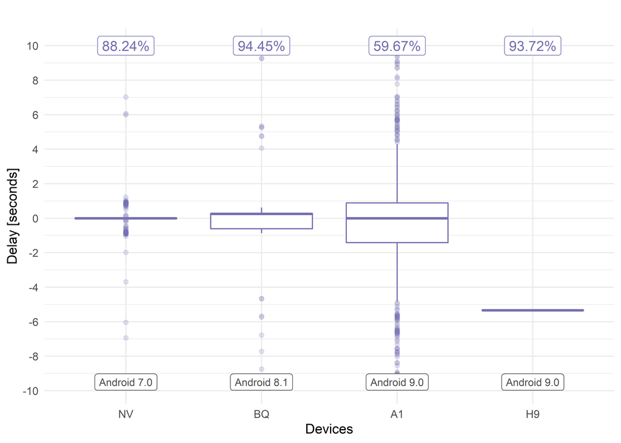

```r
performance %>%
  ggplot2::ggplot(aes(y = delay, x=device_id)) +
  geom_boxplot(color="#7570B3", fill="white", outlier.fill = "white", outlier.alpha = 0.2) +

  scale_x_discrete(limits=devices_ordered) +
  scale_y_continuous(breaks=seq(-10,10,2)) +
  # scale_color_brewer(palette = "Dark2") +

  geom_label(data = missingness_simple, aes(x = device_id, y = 10, label = percent_lbl),
            color="#7570B3",
            size=4, nudge_y= 0, nudge_x = 0) +

  geom_label(data = devices_os, aes(x = device_id, y = -10, label = device_os_lbl),
            color="grey30", size=3, nudge_y= 0.5,nudge_x = 0) +

  labs(title="", x ="Devices", y="Delay [seconds]") +
  guides(color=guide_legend(nrow = 2)) +
  theme_minimal() -> p

p
```